# Drawing ROC Curves in R with ROCR Package

Yao-Jen Kuo

Monday, September 21, 2015

# Introduction

ROC curves are commonly used in the performance evaluation of models with binary outcomes. This article demonstrates an easy example of building logistic regression with R’s built-in dataset “diamonds” and drawing ROC curves to determine which characteristic: carat, cut, or clarity best predicts whether the diamond is expensive or not. We will use `library(ggplot2)` and `library(ROCR)` these 2 packages in this article.

# Exploring and Preparing Data

Let us first check the structure and statistics summary of “diamonds.”

```r
str(diamonds)
```

```
## 'data.frame':    53940 obs. of  10 variables:
##  $ carat  : num  0.23 0.21 0.23 0.29 0.31 0.24 0.24 0.26 0.22 0.23 ...
##  $ cut    : Ord.factor w/ 5 levels "Fair"<"Good"<..: 5 4 2 4 2 3 3 3 1 3 ...
##  $ color  : Ord.factor w/ 7 levels "D"<"E"<"F"<"G"<..: 2 2 2 6 7 7 6 5 2 5 ...
##  $ clarity: Ord.factor w/ 8 levels "I1"<"SI2"<"SI1"<..: 2 3 5 4 2 6 7 3 4 5 ...
##  $ depth  : num  61.5 59.8 56.9 62.4 63.3 62.8 62.3 61.9 65.1 59.4 ...
##  $ table  : num  55 61 65 58 58 57 57 55 61 61 ...
##  $ price  : int  326 326 327 334 335 336 336 337 337 338 ...
##  $ x      : num  3.95 3.89 4.05 4.2 4.34 3.94 3.95 4.07 3.87 4 ...
##  $ y      : num  3.98 3.84 4.07 4.23 4.35 3.96 3.98 4.11 3.78 4.05 ...
##  $ z      : num  2.43 2.31 2.31 2.63 2.75 2.48 2.47 2.53 2.49 2.39 ...
```

```r
summary(diamonds)
```

```
##      carat               cut        color        clarity
##  Min.   :0.2000   Fair     : 1610   D: 6775   SI1    :13065
##  1st Qu.:0.4000   Good     : 4906   E: 9797   VS2    :12258
##  Median :0.7000   Very Good:12082   F: 9542   SI2    : 9194
##  Mean   :0.7979   Premium  :13791   G:11292   VS1    : 8171
##  3rd Qu.:1.0400   Ideal    :21551   H: 8304   VVS2   : 5066
##  Max.   :5.0100                     I: 5422   VVS1   : 3655
##                                     J: 2808   (Other): 2531
##      depth           table           price             x
##  Min.   :43.00   Min.   :43.00   Min.   :  326   Min.   : 0.000
##  1st Qu.:61.00   1st Qu.:56.00   1st Qu.:  950   1st Qu.: 4.710
##  Median :61.80   Median :57.00   Median : 2401   Median : 5.700
##  Mean   :61.75   Mean   :57.46   Mean   : 3933   Mean   : 5.731
##  3rd Qu.:62.50   3rd Qu.:59.00   3rd Qu.: 5324   3rd Qu.: 6.540
##  Max.   :79.00   Max.   :95.00   Max.   :18823   Max.   :10.740
##
##        y                z
##  Min.   : 0.000   Min.   : 0.000
##  1st Qu.: 4.720   1st Qu.: 2.910
##  Median : 5.710   Median : 3.530
##  Mean   : 5.735   Mean   : 3.539
##  3rd Qu.: 6.540   3rd Qu.: 4.040
##  Max.   :58.900   Max.   :31.800
##
```

## Creating a Binary Target: isExpensive

There is no binary variable for our target in the original “diamonds”, so let us assign that price over median: $2,400 as “EXPENSIVE.”

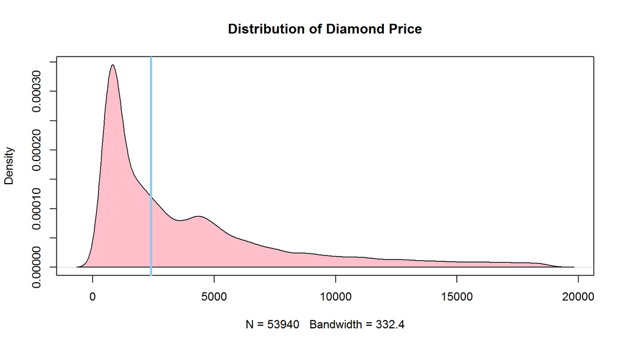

```r
plot(density(diamonds$price), main="Distribution of Diamond Price")
polygon(density(diamonds$price), col="pink")
abline(v=2400, lwd=3, col="skyblue")
```

```r
diamonds$isExpensive <- diamonds$price > 2400
```

# Training a Model on The Data

Since the number of samples are abundant, as usual, we adopt 70% for training and 30% for test.

```r
set.seed(1)
isTest <- runif(nrow(diamonds)) > 0.70
train <- diamonds[isTest==FALSE,]
test <- diamonds[isTest==TRUE,]
```

## Model 1: cut as the only predictor

```r
fit1 <- glm(isExpensive ~cut, data=train, family=binomial())
```

```r
auc1
```

```
## [1] 0.5806602
```

## Model 2: clarity as the only predictor

```r
fit2 <- glm(isExpensive ~clarity, data=train, family=binomial())
```

```r
auc2
```

```
## [1] 0.6551634
```

## Model 3: carat as the only predictor

```r
fit3 <- glm(isExpensive ~carat, data=train, family=binomial())
auc3
```

```
## [1] 0.9905482
```

# Evaluating Model Performance

Drawing ROC curves.

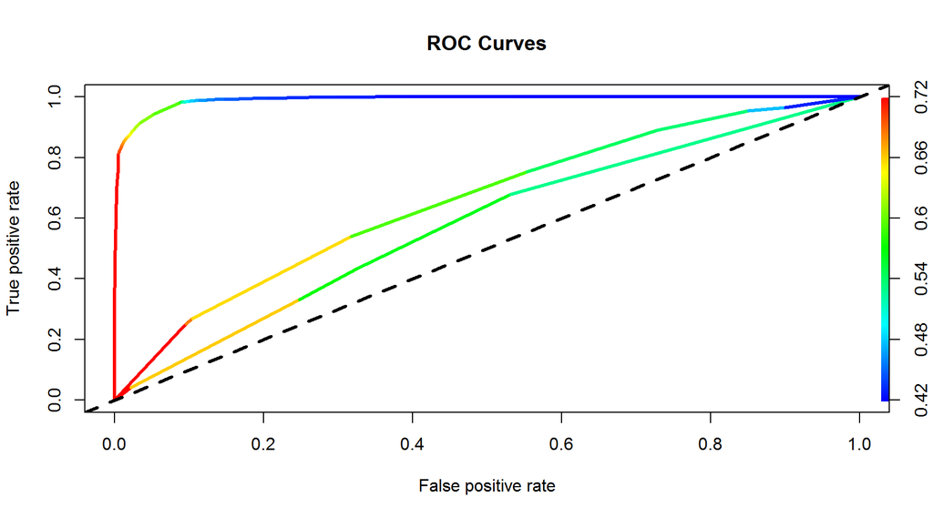

```r
plot(perf1, colorize = TRUE, lwd=3, main="ROC Curves")
plot(perf2, add = TRUE, colorize = TRUE, lwd=3)
plot(perf3, add = TRUE, colorize = TRUE, lwd=3)
abline(a=0, b=1, lty=2, lwd=3, col="black")
```

# Conclusion

- Size matters. Using $carat as the only predictor can achieve a AUC of 99%.
- We can easily build logistic regression models using `fit <- glm()` with `family=binomial()` as assigned parameter.
- We also demostrated how to generate training/test datasets from the original dataset in R.
- Most importantly, we demonstrated how to plot beautiful ROC curves.